# Part II - Bike Riding Characteristics and Usage

## by Ndjaki Ndjaki

## Investigation Overview

> In this investigation, I wanted to look at the features of bike riding that could be best for knowing when bikes are mostly used, what they are used for, and what kind of people bike-sharing system is popular with. The main focus was on start time, birth year, member gender, ride duration, days, and user type, for they appeared to be good guide on answering our investigation questions.

## Dataset Overview

> The data set includes information about individual rides made in a bike-sharing system covering the greater San Francisco Bay area. There are 183,412 individual rides in the dataset with 16 variables, where 8265 lines were removed in the preliminary wrangling process; the main focus is on ('duration_sec', 'start_time', 'end_time', 'bike_id', 'user_type', 'member_birth_year', 'member_gender', 'bike_share_for_all_trip'). Some variables of them are numeric in nature, and the others are categorical

## Distribution of Member Gender

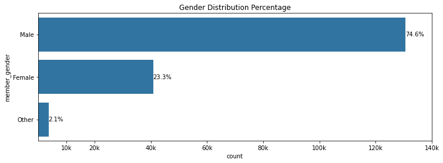

## Distribution of Ride Demand within the Week

> The demand for a ride is most important on weekdays than it is at weekend. Actually, it is as twice as on Saturdays and Sundays.

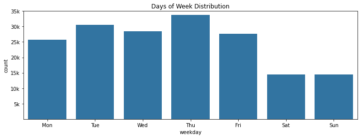

## Start Ride Time Distribution

> The distribution of start time values appears to be bimodal and spread out more or less evenly, seeming to indicate that there are two separate start time in a day. The first is morning time and the second is late afternoon The first start time pick period is from 07 AM to 09 AM The second start time pick period is from 4 PM TO 6 PM, suggesting that these are rush hours when people commute to work and come back from.

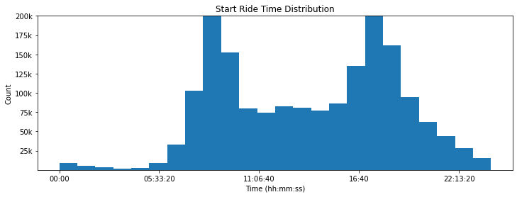

> The hsitogram top is concentrated between the year 1980 and 2000. More precisely, most of the people represented by the distribution are born between 1981 and 1996, so they belong to Gen Y (26 to 41 years old) more commonly known as Millennials

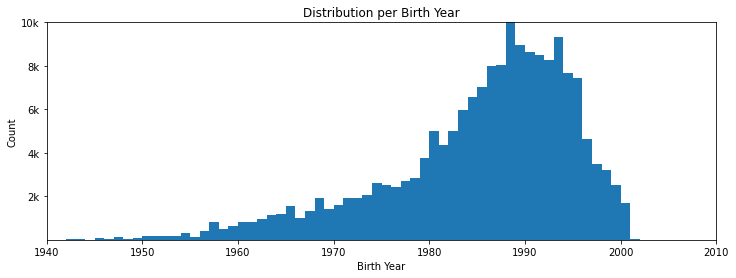

## Ride Duration vs Birth Year

> Here the amp shows that the top age group fall in a line where bike ride last less. The more they use bike, the less they spend time riding.

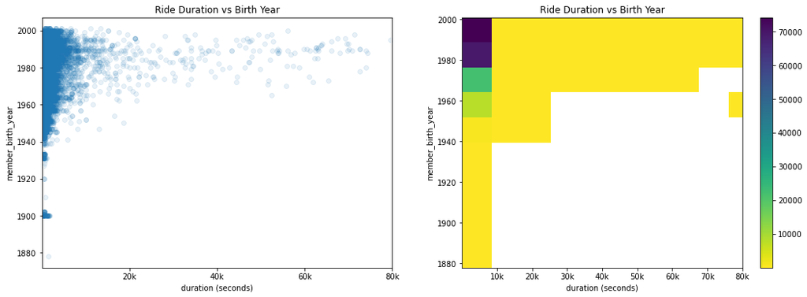

## Days Distribution per User Type

> Saturdays and Sundays gender have the closest ratio between Customer and Subscriber. Customer rides seem to be consistent across the entire week, whereas Subscriber rides present a kind of fluctuation from Monday to Friday, which makes any observation trickier on weekdays. Even if they seem to ride most on Thursday and on Tuesday.

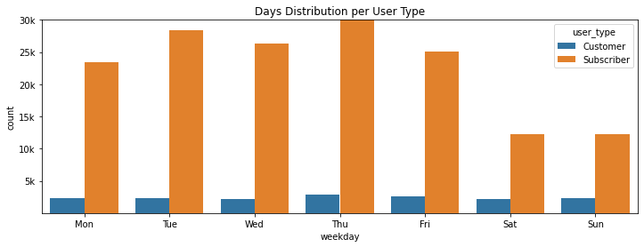

## Gender vs Birth Year

> Displaying Gender vs Birth Year on these violin and box plots shows that there is an approximate density of members birth of year for each gender. The female seem to have the higher member birth year close to the year 2000. Its long tail suggests outliers with the number of birth year isolated.

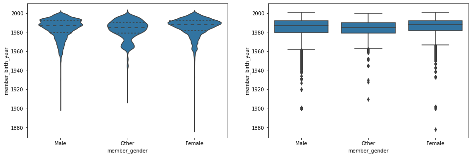

## Days and Duration by Gender

> A pick in ride duration is observed on Saturday and Sunday, conveying the idea that people use bike at weekend way longer that on weekdays

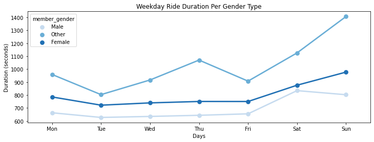

## Days and Duration by User Type

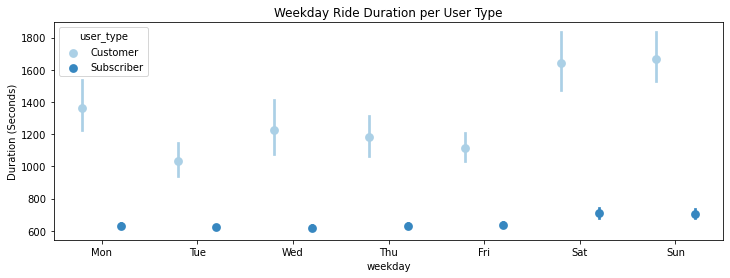